# Part II - Flights

## by Abdullah S. Othman

## Investigation Overview

This presentation explores the flights dataset that reports cancelled and delayed flights in the United States with the reasons for cancellation and delays

## Dataset Overview

The dataset has 1,280,423 flight details with 109 features.

The variables in the dataset contains information about flights' origin, departure, date and time, duration, cancellation status, delay (and cause of delay), etc.

Also, a flight is considered delayed when its arrival delay is longer than 15 minutes.

## Cancelled flights

### Proportion of cancelled flights

Out of 1.2 million flights , 23k flights (1.86%) were cancelled.

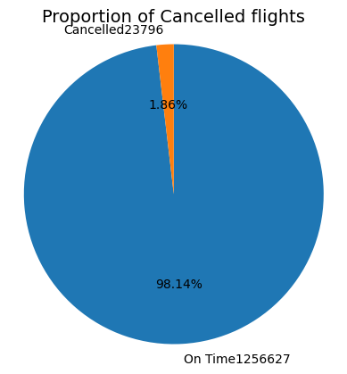

## Distribution of Cancelled flights by reason

- Most of the flights (41.88%) were cancelled due to NSA reasons followed by Carrier reasons (34.64%).
- Security reasons account the negligible proportion (4.94%) of cancelled flights.

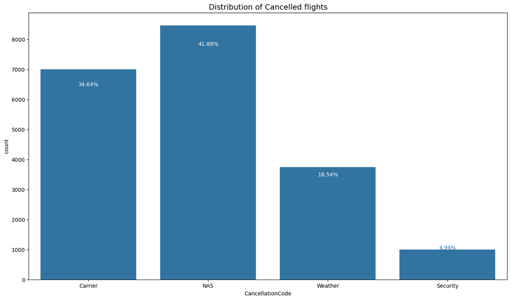

## Proportion of delays by delay cause

The maximum proportion (38.4%) of delay is caused by Late Aircraft. The Late Aircraft delay also causes the maximum average delay (~22min).

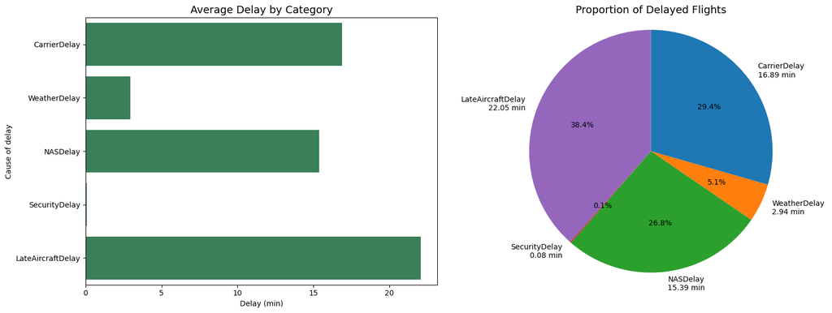

## Delayed flights by year, month and day

- On Friday, the maximum proportion (21.4%) of flights were delayed.
- December has 23.2% (maximum) of flights delayed.
- The minimum flights take place on Saturday.

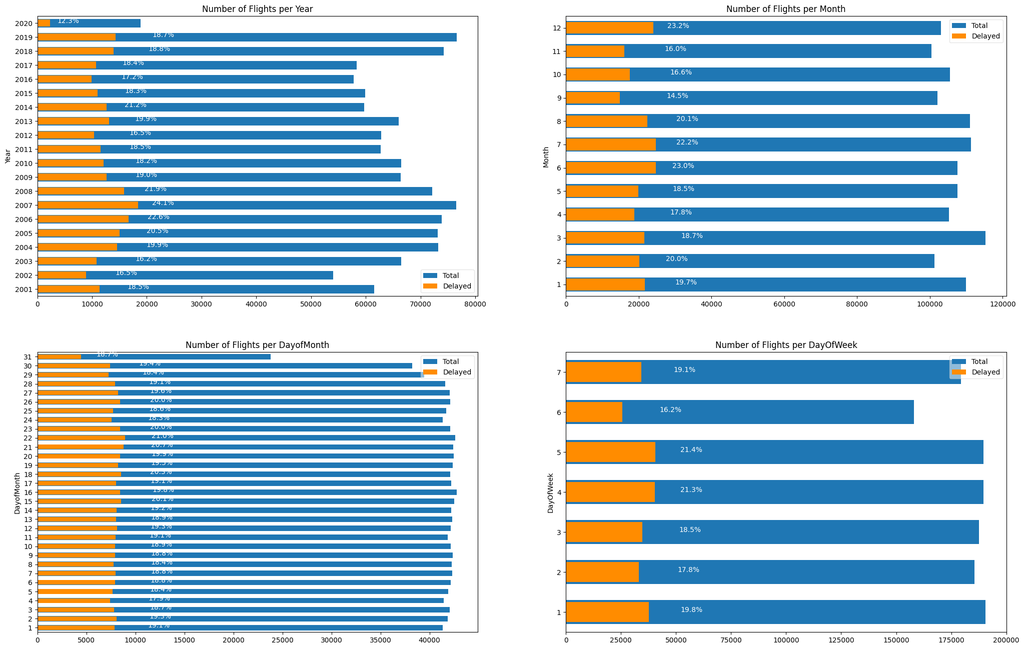